# Monitoreo Espacio-Temporal de la variación de los Glaciares Maladeta y Monte Perdido (Pirineos, España): Una Perspectiva Geomática

Mireya Fernández

Cargar las librerías necesarias

```r
setwd("E:/TFG/Series Temporales/Codigo/datos/limpio")

library(readr)
library(dplyr)
library(ggplot2)
library(lubridate)
library(readxl)
library(tidyverse)
library(tseries)
library(forecast)
library(tsoutliers)
library(expsmooth)
library(tsutils)
library (zoo)
library(imputeTS)
library(forecast)
```

# Estación de Benasque

## Temperatura

```r
archivo <- "benasque.csv"

# Leer el archivo CSV con separador ;
datosBenasque =read.csv("E:/TFG/Series Temporales/Codigo/datos/limpio/benasque.csv",sep = ";")
# Verificar las primeras filas del dataframe original para entender el contenido
print(head(datosBenasque))
```

|  | fecha | indicativo | w_med | tm_min | ta_max | ts_min | nt_30 | ta_min | e | nt_00 | ti_max | tm_mes | tm_max | nw_55 | w_racha | nw_91 | w_rec | hr | p_max | np_100 | np_001 | np_300 | p_mes | np_010 | n_cub | n_des | n_nub |
| --- | --- | --- | --- | --- | --- | --- | --- | --- | --- | --- | --- | --- | --- | --- | --- | --- | --- | --- | --- | --- | --- | --- | --- | --- | --- | --- | --- |
| 1 | ene-11 | 9838B | NA | NA |  | NA | NA |  | NA | NA | NA | NA | NA | NA |  | NA | NA | NA |  | NA | NA | NA | NA | NA | NA | NA | NA |
| 2 | feb-11 | 9838B | NA | NA |  | NA | NA |  | NA | NA | NA | NA | NA | NA |  | NA | NA | NA |  | NA | NA | NA | NA | NA | NA | NA | NA |
| 3 | mar-11 | 9838B | 5 | NA |  | NA | NA |  | NA | NA | NA | NA | NA | NA |  | NA | NA | NA |  | NA | NA | NA | NA | NA | NA | NA | NA |
| 4 | abr-11 | 9838B | 5 | NA |  | NA | NA |  | NA | NA | NA | NA | NA | NA |  | NA | NA | NA |  | NA | NA | NA | NA | NA | NA | NA | NA |
| 5 | may-11 | 9838B | NA | NA |  | NA | NA |  | NA | NA | NA | NA | NA | NA |  | NA | NA | NA |  | NA | NA | NA | NA | NA | NA | NA | NA |
| 6 | jun-11 | 9838B | NA | NA |  | NA | NA |  | NA | NA | NA | NA | NA | NA |  | NA | NA | NA |  | NA | NA | NA | NA | NA | NA | NA | NA |

```r
# Verificar la estructura del dataframe original
print(str(datosBenasque))
```

```
'data.frame':   156 obs. of  27 variables:
 $ fecha     : chr  "ene-11" "feb-11" "mar-11" "abr-11" ...
 $ indicativo: chr  "9838B" "9838B" "9838B" "9838B" ...
 $ w_med     : num  NA NA 5 5 NA NA 4 1 NA NA ...
 $ tm_min    : num  NA NA NA NA NA NA NA NA NA NA ...
 $ ta_max    : chr  "" "" "" "" ...
 $ ts_min    : num  NA NA NA NA NA NA NA NA NA NA ...
 $ nt_30     : num  NA NA NA NA NA NA NA NA NA NA ...
 $ ta_min    : chr  "" "" "" "" ...
 $ e         : num  NA NA NA NA NA NA 105 NA NA NA ...
 $ nt_00     : num  NA NA NA NA NA NA NA NA NA NA ...
 $ ti_max    : num  NA NA NA NA NA NA NA NA NA NA ...
 $ tm_mes    : num  NA NA NA NA NA NA NA NA NA NA ...
 $ tm_max    : num  NA NA NA NA NA NA NA NA NA NA ...
 $ nw_55     : num  NA NA NA NA NA NA NA NA NA NA ...
 $ w_racha   : chr  "" "" "" "" ...
 $ nw_91     : num  NA NA NA NA NA NA NA NA NA NA ...
 $ w_rec     : num  NA NA NA NA NA NA NA NA NA NA ...
 $ hr        : num  NA NA NA NA NA NA NA NA NA NA ...
 $ p_max     : chr  "" "" "" "" ...
 $ np_100    : num  NA NA NA NA NA NA NA NA NA NA ...
 $ np_001    : num  NA NA NA NA NA NA NA NA NA NA ...
 $ np_300    : num  NA NA NA NA NA NA NA NA NA NA ...
 $ p_mes     : num  NA NA NA NA NA NA NA NA NA NA ...
 $ np_010    : num  NA NA NA NA NA NA NA NA NA NA ...
 $ n_cub     : num  NA NA NA NA NA NA NA NA NA NA ...
 $ n_des     : num  NA NA NA NA NA NA NA NA NA NA ...
 $ n_nub     : num  NA NA NA NA NA NA NA NA NA NA ...
NULL
```

```r
# Verificar cuantos valores NA hay en las columnas seleccionadas
print(colSums(is.na(datosBenasque[, c("fecha", "tm_mes")])))
```

```
 fecha tm_mes
     0     40
```

Creamos la serie temporal, con los datos originales

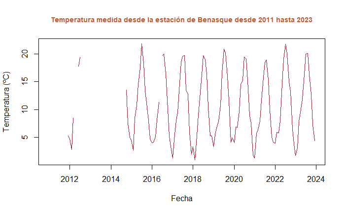

```r
temp_ts=ts(datosBenasque$tm_mes, start=2011, frequency = 12)

plot(temp_ts, pch=19, type="l",ylab="Temperatura (ºC)", xlab="Fecha", main="Temperatura medida desde la estación de Benasque desde 2011 hasta 2023", cex.main = 0.9, col="#992339",  col.main = "#c15628")
```

### **Interpolación**

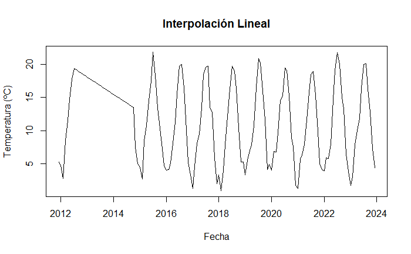

```r
# Método 1: Interpolación lineal
temp_ts_linear <- na.approx(temp_ts)
plot(temp_ts_linear, main="Interpolación Lineal", ylab="Temperatura (ºC)", xlab="Fecha")
```

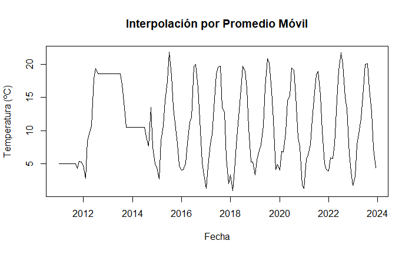

```r
# Método 2: Interpolación por promedio móvil
temp_ts_ma <- na.ma(temp_ts, k=4, weighting="simple")
plot(temp_ts_ma, main="Interpolación por Promedio Móvil", ylab="Temperatura (ºC)", xlab="Fecha")
```

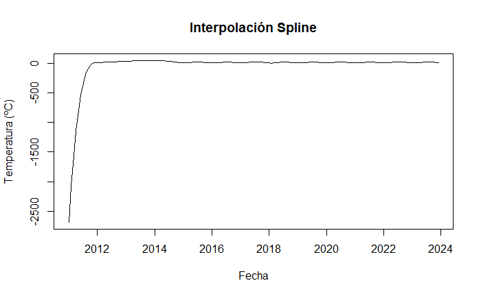

```r
# Método 3: Interpolación spline
temp_ts_spline <- na.spline(temp_ts)
plot(temp_ts_spline, main="Interpolación Spline", ylab="Temperatura (ºC)", xlab="Fecha")
```

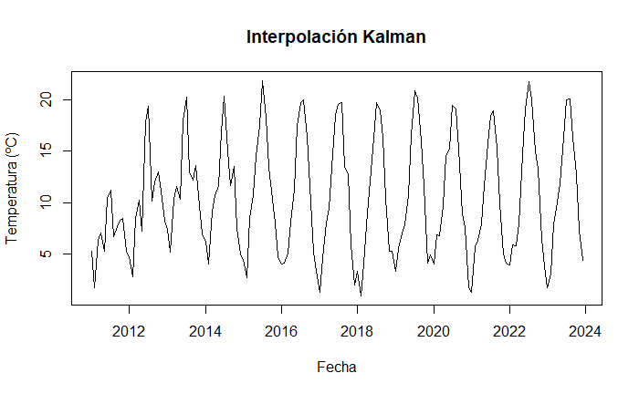

```r
# Método 4: Interpolación de Kalman
temp_ts_kalman <- na_kalman(temp_ts)
plot(temp_ts_kalman, main="Interpolación Kalman", ylab="Temperatura (ºC)", xlab="Fecha")
```

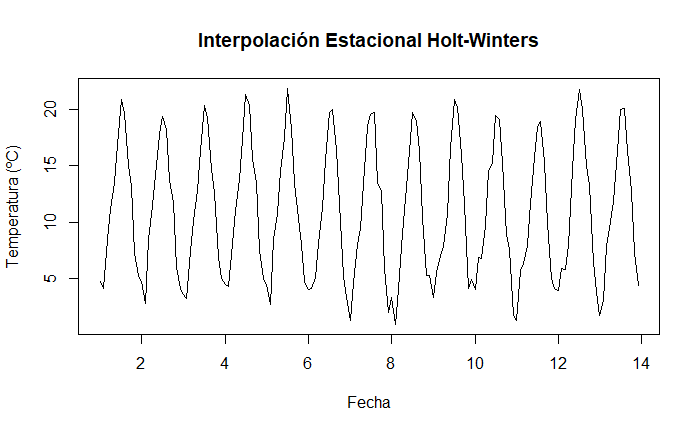

```r
# Método 5: Interpolación estacional de Holt-Winters
temp_ts_hw <- na_seadec(temp_ts, algorithm="interpolation", find_frequency=TRUE)
plot(temp_ts_hw, main="Interpolación Estacional Holt-Winters", ylab="Temperatura (ºC)", xlab="Fecha")
```

```r
NA
NA
```

### **Estudios de outliers o datos atípicos**

El estudio de los outliers (o valores atípicos) es una parte esencial del análisis de datos y la estadística. Un outlier es un dato que se encuentra significativamente alejado de la mayoría de los datos en un conjunto. Estos valores pueden ser resultado de variaciones en el sistema, errores de medición, errores de entrada de datos, o pueden ser indicativos de eventos raros pero significativos.

En el contexto de series temporales, la detección de outliers es especialmente relevante. Los datos de series temporales pueden contener outliers que representan eventos anómalos en el tiempo, como cambios repentinos en la tendencia, variaciones estacionales inesperadas, o puntos de datos que no siguen el patrón general de la serie.

El paquete tsoutliers en R se utiliza específicamente para la identificación y tratamiento de outliers en series temporales. Este paquete ofrece funciones para detectar automáticamente varios tipos de outliers, como:

AO (Additive Outliers): Puntos de datos inusualmente altos o bajos.

LS (Level Shifts): Cambios repentinos en el nivel de la serie.

TC (Temporary Changes): Cambios temporales que regresan a su nivel original después de algunos periodos.

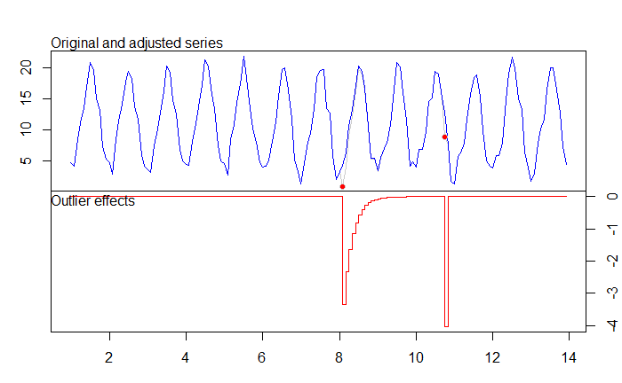

```r
temp.tsoutliers=tso(temp_ts_hw ,types=c("AO","TC","LS","IO"),maxit.iloop =10)

plot(temp.tsoutliers)
```

Existen dos valores atípicos, pero si nos fijamos en la serie original, son datos registrados por lo que no van a ser eliminados ya que son datos útiles para el estudio.

### **Análisis descriptivo**

El análisis descriptivo de una serie temporal es un paso crucial para comprender la estructura y características básicas de los datos a lo largo del tiempo. Este tipo de análisis ayuda a identificar patrones, tendencias, estacionalidades y anomalías que pueden influir en futuros análisis y modelado predictivo.

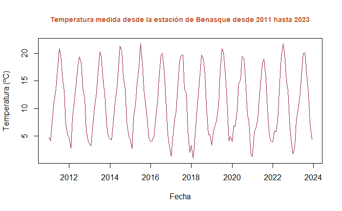

```r
temperatura_ts <- ts(temp_ts_hw, frequency=12, start=2011)
plot(temperatura_ts, pch=19, type="l", main="Temperatura medida desde la estación de Benasque desde 2011 hasta 2023",ylab="Temperatura (ºC)", xlab="Fecha", cex.main = 0.9, col="#992339",  col.main = "#c15628")
```

```r
max(temperatura_ts)
```

```
[1] 21.9
```

```r
min(temperatura_ts)
```

```
[1] 0.9
```

```r
mean(temperatura_ts)
```

```
[1] 10.9284
```

Se realiza un estudio de la tendencia y de la estacionalidad de la serie

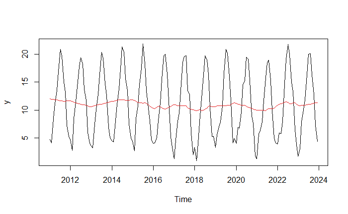

```r
cmav_temp=cmav(temperatura_ts,outplot=TRUE)
```

```r
coxstuart(cmav_temp)
```

```
$H
[1] 0

$p.value
[1] 0.0267722

$Htxt
[1] "H0: There is no change present."
```

```
Results of statistical testing
Evidence of trend: FALSE  (pval: 0.027)
Evidence of seasonality: TRUE  (pval: 0)
```

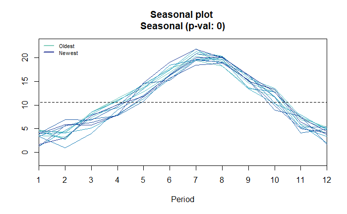

```r
seasplot(temperatura_ts, outplot = 1)
```

```
Results of statistical testing
Evidence of trend: FALSE  (pval: 0.027)
Evidence of seasonality: TRUE  (pval: 0)
```

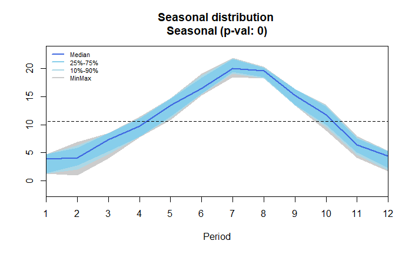

```r
seasplot(temperatura_ts, outplot = 4)
```

```
$trend
           Jan       Feb       Mar       Apr       May       Jun       Jul       Aug
2011 12.014196 11.958648 11.903101 11.847553 11.792005 11.736458 11.680910 11.625369
2012 11.659905 11.539308 11.425848 11.313479 11.204587 11.102209 11.006324 10.977361
2013 10.603177 10.685027 10.767609 10.844874 10.919207 10.993643 11.066294 11.145809
2014 11.527922 11.613050 11.698433 11.774855 11.835374 11.861160 11.863562 11.800509
2015 11.843927 11.782613 11.603052 11.375000 11.262500 11.270833 11.237500 11.275000
2016 10.299834 10.279000 10.474834 10.658167 10.599834 10.424834 10.254000 10.162334
2017 10.954167 10.937500 10.804167 10.729167 10.804167 10.779167 10.808333 10.737500
2018  9.929167  9.904167  9.995833 10.016667  9.891667 10.004167 10.141667 10.333333
2019 10.633333 10.733333 10.766667 10.800000 10.800000 10.733333 10.745833 10.833333
2020 11.183333 11.079167 11.000000 10.854167 10.887500 10.900000 10.654167 10.491667
2021 10.008333  9.958333  9.954167 10.000000  9.933333  9.925000 10.133333 10.250000
2022 10.887500 11.070833 11.104167 11.233333 11.433333 11.479167 11.375000 11.162500
2023 10.850000 10.779167 10.841667 10.875000 10.887500 10.950000 11.012488 11.074981
```

[output cut: 80 more lines]

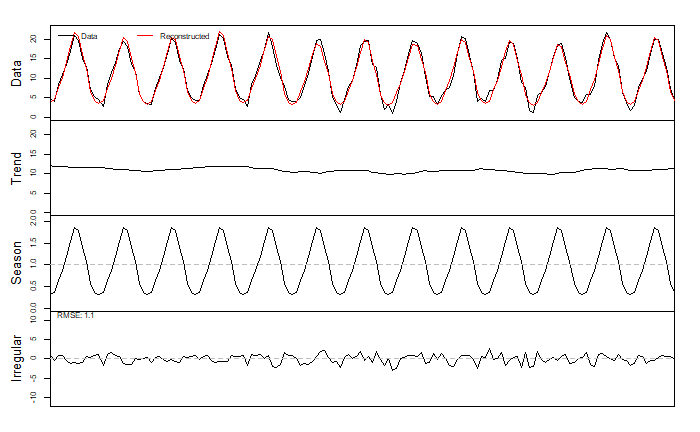

```r
decomp(temperatura_ts, outplot=1)
```

Como se observa, la serie tiene estacionalidad y tendencia estable. Por lo tanto para la creación del modelo se tendrá en cuenta esta estacionalidad.